# ENGL 306A: Linguistics

## History of Linguistics

### Medieval Grammar

- Grammar is combined with philosophy
- Assumed that grammar mirrors thought
- Nouns = permanent
- Verbs = change

### The Renaissance Europe

- More languages being studied beyond latin and greek
  - French, German, Italian, Spanish, English
- Thoughts about pronunciation and spelling
- Thoughts about evolution of language

### Reorientation

- Saussure creates a linguistic system that students publish as ‘Course on General Linguistics’
- Challenges existing linguistics
  1. Are words the same when the sound and meaning changes?
  2. Need more order, instead of an abstract, old language
  3. Linguistics should take the speaker’s point of view
     - Speakers don’t know the history of a language
- Proposal:
  - Reconstruct what a speaker needs to know to speak and understand a language
  - Includes unconscious knowledge
  - History of a language is irrelevant
  - ‘Synchronic’ approach

## Introduction

### Saussure

- A ‘word’ only has value, identity within a particular linguistic system
- System change = word change
- The past (etymology) is irrelevant

### Patterns

- Evolution of language creates consistent patterns and rules
- e.g Plural forms follow patterns (-s)

#### Exceptions

- Languages are not designed, they evolve due to historical events (e.g wars, contact with foreign language)
- e.g am/is/are/was/were
- Languages will change when used

### Language System levels

1. System of sound patterns (Phonology)
2. System of words (Morphology)
3. Rules for combining words into sentences (Syntax)
4. Rules for employing sentences in discourse (Pragmatics)

### Phonology

- Each language uses certain sounds and not others
  - e.g ‘th’ sound in english is not in italian/german
  - This makes new, differnet words possible

### Morphology

- Endings that change the meanings of words (e.g -tion, -ment, -er)
- Endings that change the grammatical significance of words (e.g -s)
- Plurals
  - English has single or multiple
  - Hebrew differentiates single, dual, multiple

### Syntax

- English: Subject - verb - object

### Challenge: Chomsky

- Agrees: linguistics is used to describe the system of language a native speaker knows
- Conflict: Linguistics needs to explain how speakers create and understant new sentences

# Phonology

## Phonetics

- Study of the production of linguistic sounds
- How are sounds produced?
- Which elements of sound are important?

### Elements of sound

1. Initiation
   - Breathe through diaphragm, lungs
2. Phonation
   - Sound moves up esophagus
   - Vocal cord vibrations produce voicing or voiced consonants (e.g ‘z’ instead of ‘s’, ‘b’ instead of ‘p’, ‘g’ vs ‘k’, ‘v’ vs ‘f’)
3. Articulation
   - Tongue, teeth, mouth movement to make different sounds by changing flow of air
   - Consonant = airflow is obstructed or constricted in some way
   - Vowel = no airflow constriction, vocal cavity is shaped
   - Actually not a clear distinction
4. Resonation
   - Sound resonate in nasal cavity and oral cavity

### Letters and Sound

- Letters are a poor representation of sound (e.g -ough, /f/)
- Writing systems are usually borrowed and don’t work well with the languages
- So double letters or diacritical marks are used to represent sounds
- Writing systems stabilize, while sounds still change
- Words are borrowed from other languages
- Word derivation wants to keep consistent spelling even if it’s pronounced differently (e.g canada vs canadian, photo vs photograph)
- Solution: Phonetic Transcription

### Phonetic Transcription

- International Phonetic Alphabet aims to transcribe sounds as accurately as possible

### Articulation: Consonants

- Defined by manner of articulation and place of articulation
- Manner of articulation
  - Obstruents: airflow is obstructed (t,f,g,s)
  - Sonorants: airflow not obstructed (r,l,m,n)
- Place of Articulation
  - Bilabial
  - Labiodental
  - Dental
  - Alveolar
  - Palatal
  - Velar
  - Glottal

#### Obstruents

- Stops (plosives): airflow is blocked
  - unvoiced: [p,k,t],
  - voiced: [b,g,d]
- Fricatives: narrow gap for air to pass through
  - unvoiced: [f,s,th,sh],
  - voiced: [v,z,the,g]
- Affricates: stop followed by fricative
  - unvoiced: [ch]
  - voiced: [j]

#### Sonorants

- Nasals: air forced through nasal cavity: [m,n]
- Approximants:
  - Liquids: [r, l]
  - Glides: [y,w] are actually unstable vowels (combo of two vowel sounds)

#### Place of Articulation

- Movable aritculaor (tongue / lips) moves towards a setable articulator (teeth, palate, etc)
- Bilabial: lips together
  - [p,b,m,w]
- Labiodental: lower lip to upper teeth
  - [f,v]
- Dental: tip of tongue to upper teeth
  - [th,the]
- Alveolar: top of tongue to alveolar ridge
  - [t,d,s,z,n,l]
- Palatal: tonge to back part of ridge
  - [sh,j,y,ch]
- Velar: tongue back to soft palate
  - [k,g,n]
- Glottal: obstruct airflow in vocal tract
  - used in british and other languages
  - `h` in ‘hat’

### Vowels

- Hard to define
- Frontness
  - Front vs Back: [beat, boot, bought]
- Height
  - Close vs Open [beat, bit, bet, bat]
- Diphthongs: double vowels that move from one articulation to another (very common in english) (e.g [ai]: pie, eye, [ao]: now)
  - Rising dipthongs: move towards high vowel
  - Centring diphthongs: move towards eh

## Phonology

- Meaning of sounds

### Phonemes

- Languages differ by which distinctive features they make *constrastive* (significant in distinguishing sounds)
- Language takes all possible sounds and divides them into phonemes
- Phonemes = families of similar sounds (similar enough that differences don’t matter in that language)
- e.g /t/ in english (stem, ten, trip, atom, atlas, bottle, pants)
- e.g In english ‘d’ and ‘th’ are different (‘den’ vs ‘then’)
  - The difference does not matter in spanish
- *Allophones* are the different versions of a phoneme that a language allows
  - e.g ‘l’ in leaopart, illness, apple
- e.g New Zealand accent crosses phoneme boundaries and words sound like different words
- *Free Variation* is if allophones are randomly distributed
- *Complementary distribution* is when allophones vary according to a scheme or rule
  - Following rules of a different language is what causes accents
  - e.g Canadians raise the first vowel of dipthongs

### Syllables

- Syllables are combinations of phonemes centred on vowel sounds, liquids or nasals
- Syllables are grouped into words
- e.g English allows consonant clusters
- Syllables can be stressed
- Consists of: onset, nucleus, coda

### Phonological Processes

- Sounds get altered in use (e.g I don’t know -> I dunno)

#### Elision / Deletion

- Subtracting of a phoneme in certain contexts
- e.g I dunno, you n me,
- e.g I saw him -> I saw ’em,
- e.g political -> plitical

#### Epenthesis

- Additional of a phoneme
- e.g warmth -> warmpth
- e.g athlete -> athelete

#### Assimilation

- One phoneme acquires a feature of a neighbouring phoneme
- In english -s is voiced if it follows a voiced consonant / vowel, unvoiced if following unvoiced
  - e.g dogs vs pets, cats vs dogs
- Voiced consonants lose their voice if followed by an unvoiced consonant
  - e.g news vs newspaper

#### Palatalization

- Consonants followed by the glide /j/(‘y’) are palatized
- e.g did you -> didya

#### Vowel Reduction

- Unstressed vowels are reduced to /ǝ/
- e.g canada -> can-eh-da, canadian -> ku-nai-dian
- e.g department -> duh partment

### Phonological Rules

- Relevant for complementary distributed allophones
- "A -> B / X__Y"
- A becomes B when preceded by X and followed by Y

#### Notation

- C = consonant, V = vowel
- Specify the phoneme (/f/)
- Classify the phoneme (voiceless stop)
- Enumerate the features of the phoneme (e.g +consonant +nasal)
- σ = syllable
- # = word
- ∅ = null (deletion or absence)

#### Nasalization

- V -> [+ nasal] / ____ [nasal consonant]
- e.g hang

#### Aspiration of voiceless stops

- voiceless stop -> [+aspiration] / ‘beginning of syllable’__[stressed syllable]

#### Flap

- [+stop +alveolar] –> /r/[+vowel], [+stress]__[+vowel -stress]
- e.g writer, rider

^ Will be tested

## Language Changes Over Time

- First (historical) law of language: Languages change
- Phonological Rules are similar to how languages change over time

### Types of Language Change

- Phonetic change
  - e.g processees
- New vocabulary
- Semantic change
  - e.g That’s so “random”
- Morphological change: change in affixes, declensions
- Syntactic change
  - e.g That’s “so” 2016

### Phonetic change: sound laws

- Addition, subtraction or changing of sounds within words
- There are ‘regular’ changes and ‘sporadic’ changes
- Regular changes alter words throughout the language
  - Take place throughout language without regard for meaning of words
- Sporadic changes only affect a random word/words

### Grimm’s law

- Laws by which Latin (PIE) changed to Gothic
- PIE (Proto Indo-European) voiceless stops become voiceless fricatives
  - [p, t, k] -> [f, th, h]
  - e.g pater -> fadar -> father
  - e.g tres -> three
- PIE voiced stops become voiceless stops
  - [b, d, g] -> [p, t, k]
  - e.g decem -> taihun -> ten
- PIE voiced aspirates become voiced stops or fricatives
  - [bh, dh, gh] -> [b, d, g]
  - e.g fero -> baira -> bear

#### Exceptions

- Latin `sto` -> `stand` (voiceless t didnt fricative)
  - New rule: voiceless stops after fricative don’t change
- Latin `dies` -> `day` (voiced stop stayed voiced)
  - Reason: English ‘day’ is not from ‘dies’, ‘dies’ became ‘tues’ (in Tuesday)

### Types of Phonetic change

- Assimilation
  - When a sound acquires characteristics of a neighbouring sound
  - e.g English plurals
- Weakening
  - Vocal articulation necessary to produce a sound is weakened
  - e.g better ‘t’ becomes a glottal stop / flap
  - e.g Latin ‘videre’ -> Spanish ‘veer’
- Loss
  - Loss often affects endings
  - Loss of consonant causes compensatory lengthening of vowel
  - e.g stanas -> stones
- Gain (Epenthesis)
  - Addition of vowel before consonant clusters
- Chain shift
  - One sound change causes other sounds to shift in response
  - e.g Chicago
    - Ann -> Ian
    - John -> Jan
  - e.g The Great Vowel Shift (1400 - 1800)
    - bat -> bate -> beat -> beet -> bite
    - boat -> boot -> bout

# Morphology

## Challenges

- A word can be two words (e.g wet suit)
- A word often has multiple meaningful units (e.g establish/ment/s)

## Morphology

- Study of smallest meaningful units in a language
- Study of how words are composed (put together)
- Morphological unit is made of phonemes

## Morpheme

- Smallest possible unit of meaningful language
- e.g house/bound
- e.g hous/ing
- e.g house/s
- e.g house

### Distinctions

- **Free morpheme**: A morpheme that can exist on its own
  - e.g ‘house’
- **Bound morpheme**: Morpheme that must be attached to a free morpheme
  - e.g Affixes
  - e.g ‘-ing’
- **Lexical morpheme**: Carries semantic weight, are an open class
  - e.g ‘house’, ‘dog’, ‘carry’
  - Usually free
  - Rare bound lexical morphemes
    - e.g (de)funct, funct(ion)
    - e.g (in)flate, (de)flate, (con)flate
- **Grammatical morpheme**: Creates or alters grammatical relations between other units, usually closed class
  - Free grammatical morphemes (Function Words): ‘to’, ‘for’, ‘in’
  - Bound grammatical morphemes: ‘-ing’, ‘ly’ ‘-s’, ‘in-’, ‘de-’, ‘con-’
    - **Derivational affixes**: Used to create new words
    - **Inflectional affixes**: Used to attach grammatical information
  - Grammatical morphemes cannot be combined to make new words

## Word-formation

1. Compounding: By combining two free morphemes
   - e.g Girlfriend
2. Derivation: By combining a free morpheme with a bound grammatical morpheme
   - e.g Friendly
   - If you change the grammatical form, it’s a inflection
     - e.g friends
3. Clipping / Acronyms: By reducing a word, subtracting from it

### Compounds

- First morpheme usually receives the stree
- Latter morpheme ‘head’ determines its word class (noun, verb, adjective)
  - Categorized as: Noun compounds, verb compounds, adjective compounds

#### Noun Compounds

- Noun + Noun
  - e.g Wheelchair, horsehair, skylight
- Adjective + Noun
  - e.g Blueberry, small talk
- Verb + Noun
  - e.g breaking point, flipchart

#### Verb Compounds

- Verb + verb
  - e.g blow-dry, sleepwalk
- Noun + verb
  - e.g manhandle
- Adjective
  - e.g dryclean

#### Adjective Compounds

- Adjective + adjective
  - e.g clear-sighted
- Adjective + noun
  - e.g gunshy, colourblind
- Adjective + verb
  - e.g stinking rich, soaking wet

#### Analysability

- Most compounds are analyzable (we can see how the compound comes from the combination)
- **Darkened compound**: Some words started as compounds, have parts that are no longer analyzable (due to sound changes)
  - e.g Cranberry (Used to be crane+berry)
- ‘Outrage’
  1. Appears to be out + rage
  2. Actually from latin ‘ultrage’ (e.g ultra)
  3. Latin ‘ult-’ -> French ‘out-’
  - Mistakenly analyzed by language users
  - Altered pronunciation to ‘outrAge’ vs ‘outrage’ (garbage)
  - Altered meaning to do with anger

### Derivations

- Free morpheme + 1+ bound lexical morphemes
- e.g Prefixes: un-, re-
  - Suffixes: -ful, -less, -tion
  - Infixes: not in english
  - Circumfixes: em—en (embolden)

#### Derivational vs Inflectional affixes

- Inflectional affixes
  - change the grammatical category of a word
  - Apply to all members of a linguistic category
- Derivational affixes
  - create new words
  - can only be attached to certain free morphemes (stems)

## Inflectional Morphology

- **Inflection** occurs when something (an affix) is added to a word to provide grammatical information
- Affix is often ‘fused’ with the free morpheme or stem
- Meaning of word doesn’t change, but we know about the context
- Not all languages are inflected

### Affixes

- Bound grammatical morphemes
- Can be derivational or inflectional
- Classified by how they attach to other morphemes
  - Prefixes: (re)turn, (pre)view, (dis)engage
  - Suffixes: turn(ing), engage(ment), view(er)
  - Infixes: Not in english, goes in the middle of a word
  - Circumfixes: (em)bold(en), (en)light(en)

### How Grammar Information is conveyed

- e.g “My father loves my sister”
  - English: word order tells us who liked whom, subject precedes verb followed by object
  - Russian: suffixes for persons will indicate who loves whom
  - Mohawk: prefix determines who loves whom, and genders
- In some languages, every word is a single morpheme
- **Isolating / Analytic language**: all words are single free morphemes
  - e.g Mandarin
- Synthetic language
  - **Agglutinative**: morphemes are added to a stem and each morpheme contains one bit of information
    - e.g Finnish, Turkish
  - **Inflecting** (Fusional): morphemes are added and usually fuse with the stem
    - Morphemes contain several bits of information
    - e.g Latin
  - Polysysnthetic
    - Words are composed of several morphemes and 1+ stem
    - e.g Mohawk: words get really long and descriptive

### Inflecting languages

- More than one morpheme per word
- Bound grammatical morphemes express more than one grammatical distinction
  - e.g Italian parl(o), -o means 1st person, singular, present tense, indicative
  - e.g Latin has a lot of inflection
  - e.g French (conjugations)

#### English Inflections

- Nouns
  - Plural: -s (Cars)
  - Genitive: -’s (Bob’s car)
- Adjective
  - Comparative: -er
  - Superlative: -est
- Pronouns
  - Nominative he, she, they
  - Accusative/Dative/Prepositional: him, her, them
  - Genitive: his, her(s), their(s)
- Verbs
  - 3rd person singular: -s
  - Progressive: -ing
  - Past: -ed
  - Past participle: -en, -ed
- e.g `she talks`
  - Indicates: 3rd person, present, not continuous, indicative mood
- Inflected verb must agree with pronoun

#### Agreement

- Pronoun and verb inflections must agree
- e.g ‘I talks’, ‘one cows’
- Important in inflected languages

### Alternatives to inflection

- **Ablaut** (Vowel Mutation)
  - e.g I write vs I wrote vs I have written
- Suppletion
  - e.g I go, they went

### Inflection vs Word Order

- English determines objects and subjects using word order
- Word order: ‘The woman gave the man a sandwich’ vs ‘The woman gave the sandwich a man’
- Inflection: ‘She gave him a sandwich’, ‘Him she gave a sandwich’

## Morphological Analysis

- Break a word into its constituent morphemes by retracing the steps of building it
  - DA = Derivational Affix
  - IA = Inflectional Affix
  - V = Verb
  - Adj = adjective
  - N = Noun
  - BL = Bound lexical morpheme?
- e.g Refocusing
  1. Split into parts: re/focus/ing
  2. Determine order parts were combined (usually derivations > inflections): ((re)(focus))(ing)

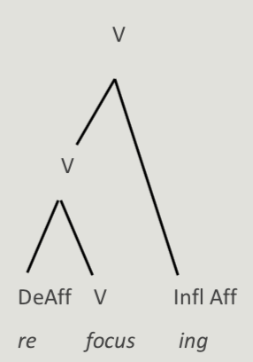

### Ambiguities

- e.g Reusable
  - re/use/able
  - ((re)(use))(able)
- e.g Unusable
  - un/use/able
  - (un)((use)(able))
- e.g Housebuying
  - house/buy/ing
  - (house)((buy)(ing))
  - Is a gerund
- e.g Reasonableness
  - Reason/able/ness
  - (Reason/able)/ness
  - N, DA, DA
  - Adj,
  - Noun
- e.g blowdryer
  - blow/dry/er
  - blow/(dry/er)
  - verb, adj, derivational adjective
  - n
  - n
- e.g Intentionally
  - In/tent/ion/al/ly
  - (((In/tent)/ion)/al)ly
  - D-aff, BL, DN, DA, D-Affix
  - V > N > Adj > Adv
- e.g Deregulation
  - De/regul/at/ion (de-/regul(ar)/-ate/-tion)
  - DA, V, DN
  - Verb > Noun

## Words as Language Units

- Words are the immediate constituents of sentences
- A broken down sentence is a sequence of words
- Languages are a collection of words (**lexicon**)
- Words bear meaning
  - Words can develop new meanings separate from their parts
    - e.g trailer =/= trail-er
    - e.g establishment =/= establish-ment
    - e.g officious =/= office-ous

## Word

- Not defined by meaningful unit
  - Suffixes have meaning
  - Some words don’t have meaning by itself (e.g in)
- Not defined by spacing
  - Some two word words have its own meaning
- Defined by ability to be moved around in a sentence
  - Different words fit different slots -> Word classes

## Word Classes

- Content Words
  - Nouns
  - Verbs
  - Adjectives
  - Adverbs
  - *Open class*
  - Semantically important
- Function Words
  - Pronouns
  - Propositions
  - Determiners
  - Conjunctions
  - Determiners (‘the’, ‘a’, demonstratives, possessives, quantifiers)
  - Degree words
  - *Closed class*
  - Syntactically important

### Determining Word Class

- Semantically: by its meaning
- Morphology: what kind of affixes and morphological change does it employ
  - e.g Can you make it plural
- Syntactically: Where and how is it used in a sentence

### Nouns

- Semantics: Signifies concrete or abstract ‘objects’
  - e.g cars, birds, love, dedication
- Morphology: Can take plural endings (-s, -es) and genitive clitics (-’s)
- Syntax: Part of subject or object of sentence
  - Agrees with verbs
  - Can be preceded by adjectives and determiners

### Verbs

- Semantics: designate processes, activities
- Morphology: conjugated according to person, number, tense, aspect, mood
- Syntax: connect to a subject
  - Can be modified by an adverb or adverbial phrase
  - Take complements (verb is used as the object of another verb)
    - e.g I *asked* her to *leave*

### Adjectives

- Semantics: designate an attribute of something or a quality
- Morphology: no case endings, can take comparative endings (-er, -est)
  - can be derived from nouns using suffixes (-y, -ful, -less)
- Syntax: can be a complement to a verb phrase (e.g “The sky is blue”)
  - Can be before a noun that it modifies
  - Cannot be the subject or object in a sentence

### Adverbs

- Semantics: designate an attribute of an activity
- Morphology: no case endings
  - many end in `-ly`
- Syntax: Appear before or after what they modify
  - Can modify anything but a noun (including adjectives)

### Pronouns

- Semantics: refers to a person or thing already referred to
- Morphology: declined for genitive, sccusative/dative cases
  - inflected
  - e.g he, his, him
- Syntax: like nouns

### Prepositions

- e.g in, to, for, at, with, about, near, of
- Semantics: refers to relations between things or between an action and its object
- Morphology: invariant
- Syntax: always linked to a prepositional object
  - prepositional phrases can function as complements to verbs
  - or modifying a verb or noun phrase

### Determiners

- e.g the, a, this, that, these/those
- Semantics:
- Morphology: generally invariant, except these/those
- Syntax: front of noun phrases

### Conjunctions

- e.g and, or, but
- Semantics:
- Morphology: invariant
- Syntax: connect words, phrases or independent clauses
- Types:
  - coordinating: elements are conjoined in parallel
    - e.g and, or, but, yet, so
  - subordinating: one element becomes a subpart of the other
    - e.g that, when, if, after, because, although, wherever
  - correlative: links things, but requires both parts
    - e.g either … or, both … and, not only … but also

### Degree Words

- e.g very, so, too, always, perhaps, most
- Semantics:
- Morphology: invariant
- Syntax: appear before adjectives and adverbs

### Ambiguities

- Words in different classes may have the same suffixes
  - e.g approaches
- Words in different classes may have the same form
  - e.g “the fast bus” vs “he runs fast”
- Verbs can be used as nouns (gerunds)
  - e.g “Running was his favourite sport”
- Adjectives can be used as nouns
  - e.g “Empty was the feeling he had”
- Adverbs can be used as a degree word
  - e.g “he was terribly dull”
- Phrase or clauses (composed of different word classes) can function like an adverb, adjective
  - e.g “He taught his class with extraordinary enthusiasm”

### Semantics

- Study of the meanings of words
- Concerned with
  - nature of meaning

### Sources of New words

- Derivation (adding affixes)
- Borrowing from other languages
- Formal processes (compounding, clipping, blending, acronyms, word-class conversion, back-derivation)
- Word can change its meaning (this makes it a new word)

### Borrowing

- People move around, trade and interact with other languages
- Words are adapted to sound patterns of host language
- 70%+ of modern english is borrowed
- e.g Pronouns
  - German: I, thou, she/he, you
  - Scandinavian: they
- e.g Adaptation
  - pay-jamahs (Persian) -> pyjamas
  - segankw (Abenaki) -> skunk
- Loan words look different from other english words

### Formal Processes

- Compounding: Make new words by sticking together existing words
  - e.g air + port
  - e.g wind + surfing
- Clipping: Take a word and delete part of it
  - e.g hamburger -> burger
  - e.g professor -> prof
  - e.g demonstration -> demo
  - e.g network -> internet -> net
- Blending: take a bit of each word and combine them
  - e.g smoke + fog -> smog
  - e.g motor + hotel -> motel
  - e.g breakfast + lunch -> brunch
  - e.g wireless + fidelity -> wifi (also analogy to `hifi`)
  - e.g waterloo + card -> watcard
- Acronyms
  - Letter enunciation:
    - e.g PR, TV, R&R, USA,
  - Pronounced:
    - e.g RADAR, NASA, AIDS, DOS,
- Back-derivation: create new words based on another new word
  - Removing supposed affixes
  - e.g stage + manager -> stagemanager -> stagemanage
  - e.g tele + vision -> television -> televise
  - e.g firefighter -> firefight

### Meaning to make words

- A sound pattern is not a word until it becomes meaningful
- e.g Same sound, different meaning
  - ‘Yellow blue tibia’ means ‘I love you’ in russian

#### What does meaning mean?

- *Signifier*: Concept or idea attached to the sound pattern (the *signified*)
- *Reference*: Thing in the world that the sound pattern refers to
- We call signifier ‘meaning’

#### Networks of meaning

- Words acquire new meanings over time
- Words gain a network of related meanings
- e.g Trip has many related meanings (walk, journey, stumble, stumble in speech)
- e.g School
  1. Institute of learning
  2. Lessons
  3. Students and staff
  4. Group of people with similar views (‘school of thought’)
  5. group of artists with the same style
  6. group of fish (actually from dutch)
  7. an educational experience (‘school of life’)
  8. to outwit or display mastery (‘to school someone’)

#### Meaning Evolution

- Metonym: refer to something by something closely associated
  - e.g ‘Ottawa’ as a parliament hill
- Metaphor: the thing said is like the thing referred to
  - Way for words to acquire new meaning
  - e.g School of life
- Generalization: new meaning is broader
  - e.g ‘Schooling is important’ refers to every kind of education
- Specialization: acquire new meaning that is more specific than basic meaning
  - e.g Summer school
- Word-class conversion: When one kind of word is used like another kind of word
  - e.g old school (‘school’ as adjective)
  - e.g to school someone (‘school’ has a verb)
  - Often the stress on the word changes
  - e.g ‘computer’ was a person who made calculations
    - Became: Device/machine for preforming calculations

### Onomasiology

- Theory of naming
- Look at the meaning, of the word and then the name
- **Conceptual domain**: Group of signifieds (sound patterns)
  - e.g animals, human body

#### Lexical Fields

- Words that cover a conceptual domain
- e.g lexical field of animals
  - dogs, cats, snakes
  - No unity
  - Comes from a variety of sources
    - Adjective forms are from latin
    - Food forms are from french
  - Has distinctive words for males, females, children, groups
- e.g lexical field of chemistry is more homogeneous
- Lexical field reveals historical technologies

# Syntax

- Study of how we put words together in sentences

## Syntax and Grammar

- Words need to be arranged in an order
- Sentences can be non-nonsensical, but grammatical (e.g Jabberwocky)

### Syntactic rules

- Rules by which we combine words into sentences
- Descriptive, not prescriptive (what people do, not what people should do)
- Rules about combining different classes of words
- Language speakers just ‘know’ these rules, and ‘know’ the vocabulary (where each word can be used)
  - e.g ‘kills’ is a verb
- Violations of a rule results in incorrect sentences
  - e.g “Kills Joe” needs a subject
  - e.g “Joe without needs Sam”

### Sentence

- Sentences are not strings of words
- Sentences are composed of discrete combinations of words, which stick together
  - e.g (The mathematics student) found (the crates of books (with torn pages)) (in the hallway)
- **Hierarchical**: rules tell us how to build progressively larger sentences
  - e.g “Barry looked up Ellen’s phone number” vs “Barry looked up Ellen’s nose”
    - Barry (looked up) Ellen’s phone number
    - Barry (looked) (up Ellen’s nose)
- The word groupings determines how words can be moved around
- **Constituent Sentences**

### Constituency Tests

- **Transposition**: moving phrases around
  - e.g “The mathematics student (put) (the crates of books with torn pages) (in the hallway).”
    - Incorrect: “(The crates of books with torn pages) (in the hallway) were (put) by the mathematics student.”
    - Correct: “The crates of books with torn pages were (put) (in the hallway) by the mathematics student.”
      - “in the hallway” needs to be with “put”
- **Fragments**: rephrase sentence as question and answer
  - e.g “The mathematics student put the crates of books with torn pages in the hallway.”
    - Incorrect: “What did the mathematics student put? The crates of books with torn pages in the hallway.”
    - Correct: “What did the mathematics student put in the hallway? The crates of books with torn pages.”
- **Substitution**: replace noun phrases with ‘one’/‘ones’/‘them’/‘it’, and verb phrases with ‘did’/‘did so’
  - e.g “The mathematics student put the crates of books with torn pages in the hallway.”
    - Incorrect: “The mathematics student put the crates of books with torn pages in the hallway and the ones with good pages on the bookshelf.”
    - Correct: “The mathematics student put the crates of books with torn pages in the hallway and the crates of ones with good pages on the bookshelf.”

### Syntactic Analysis

- Determine which parts of the sentence form a structure with other parts
- **Projection**: phrases that extends the word class of the words its made of
  - Noun phrases, verb phrases, adjective phrases

### Components of Phrases

- **Head**: ‘fundamental’ word in each phrase
- **Complement**: something we *must* add to the head
  - Only one complement
  - Cannot be moved around without the head
  - Can be a phrase
  - e.g Head: ‘found’ requires a object complement
  - e.g Prepositions have complements
- **Adjunct**: something *optional* we add
  - Can have many adjuncts
  - Can be a phrase
  - e.g ‘Torn pages’, ‘torn’ is an adjunct
- **Specifier**: word that completes the phrase

### Syntactic Rules

- ->: consists of
- (X): X is optional
- X*: There can be many X’s
- { }: X or Y

#### Noun Phrases

- Head is a noun
- Complements:
  - To determine if its a complement, try substituting ‘ones’
    - Noun must be substituted with its complement
- Adjuncts:
  - Can have adjective, propositional phrase adjuncts
  - Cannot have adverb adjuncts
- Specifiers:
  - Determiner
- e.g “the hallway”: has a determiner before it
- e.g “torn pages”: ‘torn’ is an adjunct
- e.g “the crates of books”: hard to split ‘crate’ from ‘books’
  - ‘crates’ = complement
- ‘Dumb subjects’: Subjects that don’t actually mean anything
  - e.g it, there

##### The noun rule

- **NP -> (Det) (AP)* N (PP)**
- Noun phrase has:
  - Head: noun
  - (optional) Complement
  - (optional) Adjuncts: adjective phrase, prepositional phrase
  - (optional) preceded by a specifier

#### Adjective Phrases

- **AP -> (Deg) (Adv) A**
- Can be used attributively or predicatively
  - **attribute**: complement in a noun phrase
    - e.g “a *beautifully* wrapped present”
  - **predictive**: part of a verb phrase
    - e.g “the present was *beautifully* wrapped”
- Can have complements and adjuncts
- Modified by degree words
- Modified by adverbs

#### Adverbial Phrases

- **AdvP -> (deg) Adv (PP)**
- Can modify anything except nouns
- Head is an adverb
- Takes prepositional phrases as complements
- Adjunct: degree words

#### Prepositional Phrases

- **PP -> P NP**
- Head: preposition
- Complement: noun phrase
- Can be used as a complement in a verb phrase
- Can be used to specify location
- Can be used to specify an object in a verb phrase

#### Verb Phrase

- **VP -> (Aux) V (NP) (NP) (AdvP)* (PP)***
- Every sentence contains a verb
- Verb determines overall shape of sentence
- Complement:
  - **Intransitive**: does not require any complements
    - e.g “She *relaxed*”
  - **Transitive**: requires a noun phrase complement
    - “She *insulted* (Eleanor)”
  - **Prepositional**: takes a prepositional phrase complement
    - “She *looked* (at the sky)”
  - **Ditransitive**: requires two complements
    - “She *gave* (her) (a gift)”
    - “She *took* (her) (to the cleaners)”
  - When the complement is a noun phrase, we call it an **object**
    - e.g “Patricia whacked (Eleanor)”
- Adjunct: Prepositional phrase
  - Note: sometimes the PP is a complement
- Identify complement vs adjunct
  - Substitute ‘did’ or ‘did so’

### Constituency Test

- Used to identify phrases using our intuitive understanding of grammar
- Tests:
  - **Passive test**: put sentence in passive and see what happens
    - e.g “The crates of books with torn pages were found by the mathematics student in the hallway”
  - **Substitution test**:
    - Substitute `did`/`did so` for verb phrases
    - Substitute `ones`/`them`/`it` for noun phrases
  - **Fragment test**: see how the sentence is split when you ask a question
    - e.g “What did the student find in the hallway?” “The crates of books with torn pages”
  - **Parallel test**: make a parallel phrase
    - “The student found crates of books with torn pages and missing covers.”

### Embedding and Hierarchy

- Each phrase can stand on its own or be part of a constituent structure within a larger phrase

## Syntax Trees

- Representation of the hierarchical structure of a sentence
- Set of claims about constituent structure
- Interpretation/analysis of the sentence
  - e.g Interpretation
    - “They (finished their walk) (in the garden)” or “The finished (their walk in the garden)”

### Terms for Tree Diagrams

- **Branches**: connection between two nodes
- **Nodes**: a branch point (?)
- **Immediately** dominates: (verb) “Mother *immediately dominates* the daughter”
- **Mothers**: direct-parent node
- **Daughters**: child node
- **Sisters**: nodes with the same mother

### Constructing a Tree

1. Identify words by word class
2. Combine them into basic phrases
3. Separate the sentence into subject and predicate (NP and VP)
4. Analyze child structures until we reach word level

Examples - “The student read the book” - “((The student) (read (the book)))” - “The student read the book of poems” - “((The student) (read (the (book (of poems)))))”

### N’ and X-bar Theory

- `N'` is a constituent structure found between word classes and phrases
  - Represents the constituent resulting from combining a head and its complement
  - e.g “(book of poems) with torn pages”
- N’ is a new level in a tree

#### Noun phrase rules

- NP immediately dominates the specifier and a N’
- Adjunct will be sister to an N’ and daughter to an N’
- e.g “a strikingly hairy dog”
  - `[NP [Det a] [N' [AP [Adv strikingly] [A hairy]] [N dog]]]`
- e.g “the strikingly hairy dog on sale”
  - `[NP [Det the] [N' [AP [Adv strikingly] [A hairy]] [N' [N dog] [PP [P on] [N sale]]]]]`

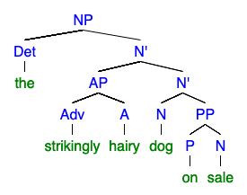

- e.g “the strikingly hairy dog that he saw in the park”
  - `[NP [Det the] [N' [AP [Adv strikingly] [A hairy]] [N' [N dog] [CP [C that] [S [N he] [VP [V saw] [PP [P in] [NP [Det the] [N park]]]]]]]]]`

### Distinguishing Complements and Adjuncts

- Nouns
  1. *Substitution* (One-replacement)
     - If you can replace the N with “one”, its sister is an adjunct
  2. Complements are closer to the head
     - Cannot insert anything between a complement and its head
  3. Adjuncts can be conjoined
     - e.g “the book of poems with torn pages”
       - “the book of poems with torn pages and with a blue cover”
       - *“The book of poems and of short stories”
- Verbs
  1. *Substitution*
     - Replace the verb with “did” or “did so”

### X-bar theory

- For each phrase, there is a ‘bar’ constituent (V’, A’, etc)
- X’ is mother to the head and the complement, and sister to adjuncts

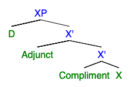

## Complex Sentences

- Sentences with more than one subject and predicate

### Clauses

- **Clause**: Syntactic unit that contains a subject and a predicate
  - Includes a verb phrase
- *Simple sentence*: sentence with one clause
  - e.g “Most students enjoy long, difficult examinations”
- *Complex sentence*: sentence with multiple clauses
  - e.g “(Most students enjoy examinations) (when they are extremely difficult)”
  - e.g “Most students (enjoy examinations) that (really test their knowledge)”
  - e.g “(Professors like to write examinations) when they (have nothing better to do)”
  - e.g “Exams that (last for hours and hours) (make students deliriously happy)”
- **Independent clause**: Clause that stands on its own and doesn’t need anything else

### Verbs

- All clauses contain a verb phrase
- Independent clauses must contain a **finite verb**
  - Marked for tense, person, number, aspect, etc. (Displays agreement)
  - In English the verb may not appear marked (e.g ‘enjoy’)

#### Auxiliary Verbs

- VP -> (Aux) V (NP) (NP) (PP)*
- Verb phrases may contain auxiliary verbs
- e.g ‘can’, ‘has’, ‘might’, ‘is’, ‘doesn’t’
  - “He *can* run very fast”, “He *has* spoken to her about it”
- Types
  - **Modal Auxiliaries**
    - `Can/could, shall/should, may/might, will/would`
    - Expresses possibility, ability, permission or allowance
    - Does not inflect like ordinary verbs
      - No `-s` suffix in the 3rd person singular
  - **Aspectual Auxiliaries**
    - `is, have`
    - Expressed ‘aspect’, if something is completed or continuous
- Used in combination with main verbs
  - Becomes the finite verb, and the main verb is not finite
  - e.g “You have run”, “He has run”, not “He have ran”
  - *Note*: ‘have’ and ‘is’ are also main verbs
  - Can have multiple auxiliaries
    - e.g “He *would* *have* been a terrific Prime Minister”
    - e.g “They *may have been* working late”
    - In these cases, the initial verb is the true auxiliary (it is the only finite one)
      - If turned into a question, the initial verb is at the front
        - e.g “Would he have been a terrific Prime Minister?”
- Don’t need to indicate tense on Auxilliary nodes
  - Just make I the mother of the Aux node with no sisters

#### Infinitive Verbs

- Non-finite
- Non-marked, general form of the verb
- Accompanied by the preposition `to`
  - e.g “To run for President, you must be an idiot.”
  - e.g “He had to admit it was dumb.”

#### Participles

- Non-finite
- Used in conjunction with aspectual auxiliaries
- Present participle:
  - Suffix `-ing`
  - e.g “He is admitting the patient now.”
  - e.g “Thinking quickly, he admitted nothing.”
- Past participle
  - Lots of variations
  - End in `-ed`: ‘made’, ‘viewed’, wanted’
  - End in `-en`: ‘written’, ‘broken’, ‘given’
  - Use ablaut: ‘rung’, ‘swum’
    - e.g “She was defeated by a better player.”
    - e.g “He had written her a long letter.”
    - e.g “He as rung her repeatedly.”
  - Can also be used as adjectives
    - e.g “He was a broken man.”
    - e.g “His written notes were hard to read.”

### Diagramming Finite Verbs

- `I` node indicating inflection
  - `VP` complement
  - `I'` mother
- Combined with sister `NP` node with mother `IP` node

### Complex Sentences

- Consists of a *main clause* and a *subordinate clause*
- **Main Clause** contains a finite verb
- **Subordinate Clause**
  - Can have finite or non-finite verbs
    - Don’t need to diagram finiteness of verbs in the subordinate clause
  - Does not need a noun phrase
- **Relative Clause**:
  - Subclass of subordinate class where the subordinate clause modifies a head noun.
  - Usually has the conjunctions [who, which, that]
    - e.g “The man who *came to dinner was very dull*”
    - e.g “He wrote a book that *sold ten thousand copies*.”
    - e.g “We saw the film that *our friend had recommended*.”
- Tree Diagram:
  - `C`: Complementizer
    - e.g that, to, when
      - ‘to’ is a complementizer when it precedes a verb, preposition when it precedes a noun
    - Can be skipped
  - `CP`: complement phrase
  - `S`: subordinate clause
  - `IP` at the top

## Examples

My sister and I wanted to escape and see the world.

```
[IP [NP [NP [Det My] [N sister]] [C and] [N I]]
    [I' [I -ed] [VP [V wanted] [CP [C to] [VP [VP [V escape]] [C and] [VP [V see] [NP [Det the] [N world.]]]]]]]]
```

# Discourse

- 4th level of language analysis
- Actual speech and use of language
- Subfields: pragmatics, stylistics, sociolinguistics, conversation analysis, politeness theory

## Elements of Discourse

- Intonation
  - Lacked by text-to-speech software
  - Indicates questions
- Bodily movements and facial expression
- Colloquial and idiomatic expression
- Abbreviations (e.g Later, Whatever, LOL)
- Stylistic features (formal and informal language, slang, technical and ordinary language, etc.)
- Conventions of politeness, conversational norms

## Émile Benveniste

- Language takes meaning from discourse

### Pronouns

- Traditional division
  - 1st person: I/we
  - 2nd person: thou/you
  - 3rd person: he/she/they
- They are used differently
  - I/You refer to specific people (speaker, addressee) that only make sense in discourse
  - He/she/they refers to someone else you bring up

### Deixis

- *Deictic*: Expressions that ‘point’ to an object
  - e.g `this, that, these, those`
- Don’t mean anything outside of a context where they point to something
- Similar: expressions of time
  - e.g `now, later, tomorrow`
- Objective vs ‘instance of discourse’:
  - here : there
  - today : the very day
  - tomorrow : the following day
  - three days ago : three days before

### Verbs

#### Finite Verbs

- Finite verbs have tense, so they refer to events relative to the moment of discourse
- e.g “I was going far away from here”
  - “here” refers to current location
  - “was” relative to current time

#### Verbal Meaning

- Some verbs change meaning depending on first or third person
  - e.g “he swears” (description of action) vs “I swear” (pledge)
  - e.g “he promises” vs “I promise”

## Jakobson’s model of language

- Every speech even has 6 elements
  - Context
  - Message
  - Contacta
  - Code
  - Addresser
  - Addressee

### Referential Function

- Aspect of message oriented towards something in the context
- Is true or false
- e.g “The sky is blue”, “Ellen is running away”, “Linguistics is fascinating”

### Emotive function

- Aspect of message oriented towards feelings or attitudes of the addresser
- Expresses outwardly something the speaker thinks/feels inwardly
- e.g “My tooth hurts”, “I’m bored”, “That’s disgusting”

### Conative function

- Aspect of message oriented towards influencing the addressee
- Orders, persuasive, insulting, etc.
- e.g “Stand over there”, “You shouldn’t do that”

### Phatic function

- Aspect of message oriented towards link between addresser and addressee
- Maintains relationships through language
- Not much meaning, but it ‘oils the wheels of conversation’
- e.g “Hi!”, How are you?“,”…isn’t it?“,”Who knew?"

### Poetic function

- Aspect of message oriented towards the language of the message itself
- *Literary* element where forms of language are stressed
- e.g “I have eaten / the plums that were in / the icebox / …”

### Metalingual function

- Aspect of message concerned with underlying structure or code of language itself
- Reflecting upon language within language
- e.g Linguistics class, grammar correction

## Conversation and Politeness

### Conversation: Initiating

- There are routines used to initiate conversations
- ‘Summons-Answer’ sequence
  - A: summons
    - Takes form of:
      - Physical movement (e.g waving, tap on shoulder)
      - Term of address (e.g “John?”, “Miss?”)
      - Courtesy phrase (e.g “Excuse me”, “Hey you”)
    - The term of address can be inserted anywhere without regard for grammar
  - B: Answers in order to continue conversation
    - Has a time limit
  - Sequence must be continued
  - Sequence can’t be repeated
  - Establishes willingness to converse
    - vs sulking, cold shoulder

### Conversation: Turn-taking

- People take turns in a conversation
- 1 person speaks at a time
- Ways of marking where a change of speakers (a *transfer*) can occur
  - Stoppage points where someone else can take a turn
- There are rules for who can speak next at time of transfer
  - Current speaker can choose or self-selection depending on who speaks first
- Rules for dealing with silences
  - Natural gaps between turns
  - *Lapse*: Substantial gap between turns
  - If the next speaker has been selected, it’s just a *pause*

## Politeness

- Politeness conventions are *phatic* (pertain to the social relationships we establish and maintain by means of speech)
- Language and culture-specific
- Shapes language in different ways:
  - Syntax: use of directed or indirect constructions
  - Terms like ‘please’, ‘may’, ‘thank you’
  - Naming and Address

### Naming and Address

- In many languages pronoun use varies depending on age, status, familiarity
  - e.g French ‘tu’ vs ‘vous’
  - e.g German ‘du’ vs ‘Sie’
  - e.g 你 vs 您
- Terms of address in decreasing order of familiarity reciprocally (opposite non-reciprocally)
  - Surname + social title (e.g “Mr. Smith”)
  - Surname + professional title (e.g Professor Smith)
  - Surname (e.g Miller)
  - Title / kinterm + given name (e.g Aunt Ella, Granny Rose)
  - Kinterm (e.g Mom, Dad, Auntie)
  - Given name (e.g Robert)
  - Standard short form: (e.g Rob, Bob)
  - Nicknames (e.g Bobby)
- Other terms of address
  - Bare Title (e.g Doctor)
  - Respect terms (e.g Sir, Ma’am)
  - Stranger generic names (e.g Bud, Mac)
  - General (e.g man, you, guys, dude, mate)
  - Insults (e.g bastard, slimeball, bitch)
  - Endearments (e.g honey, sweetie, love)
  - *These are used in different situations*
    - Can be used ironically
      - e.g ‘bitch’ as endearment
      - e.g ‘love’ as general term (UK)
      - e.g ‘brother’ to non-brothers

### Speech Acts

- Some verbs have different significance when used in first-person
  - e.g “I do”
  - e.g “I bet you a dollar that…”
  - e.g “I…” ‘apologize’, ‘swear’, ‘promise’, ‘approve’, ‘sentence you to’, ‘find you guilty’
  - e.g “Don’t touch that!” (warning)
  - e.g “Notice is *hereby* given that trespassers will be prosecuted”
- You are actually doing the thing, not describing it as for other sentences
- Called **Performatives**
- Can succeed or fail (not true or false)
  - Circumstances need to be in place
  - Speaker needs to be qualified to commit the act
  - Needs to follow procedure or convention that is understood by participants
  - Circumstances required by the procedure must be met
    - e.g Legal requirements, age of consent
- Failures
  - The effect has no *force*
  - Failure is due to external circumstances
    - Except when you make an insincere promise which you shouldn’t do
- How to tell:
  - Performative isn’t true or false, but successful or not
  - Performative is done by saying it
  - Can add ‘hereby’
- Other performatives
  - “That is a big puddle” (as a warning)
  - “I wouldn’t do that if I were you” (to a friend that wants to borrow your phone)
    - Is a threat
- Ambiguities
  - “I am sorry”
    - Apology or reporting your feelings?
  - “You’re out!” (by umpire)
    - Declaring someone out, or reporting a fact
  - “I agree with you”
    - Agreeing, or describing state of mind

#### Force

- Do all utterances have force?
  - Everything you say has a motive
- Types of force
  - **Illocutionary force**: force that the words have, that depend on what you say
    - Explicit
    - “In saying X, I am doing Y”
    - e.g promising, stating, guessing, informing, warning
  - **Perlocutionary force**: achievement of certain effects by saying something
    - Effect the utterance has on others
    - “By saying X, I am doing Y”
  - e.g “I will hit you if you step over that line”
    - *Illocutionary* force of threatening
    - *Perlocutionary* force of intimidating
  - e.g “You have a wonderful laugh”
    - *Illocutionary*: compliment
    - *Perlocutionary*: flirting

# Linguistic Variation: Dialects

## Variation in Language

- Speaking the same language does not mean using the same words / grammar / pronunciation
- Language will evolve within a group

### Latin and the Romance Languages

- Roman empire: Latin was a shared language across Southern Europe
- Fall of roman empire: parts became isolated
  - Languages diverged and became French, Italian, Spanish, Portuguese and Romanian
  - *Actually*: Latin first dissipated into hundreds of local *dialects*
- We think of ‘languages’ as what a nation speaks

### Standardization

- *Standardization*: Governments tries to homogenize the speech of its inhabitants
  - Choose a dialect and make that the ‘model’ dialect
- Method:
  - Creation and circulation of printed texts
    - Printers need to choose a standard form of variant words, spelling, grammar
  - Adoption of a dialect for official use
  - By government rule
  - By education
- e.g French revolution
  - We need to have a national language to be a free country
- Timeline
  - England: ~1600
  - France: after French Revolution
  - Italy: 20th century
  - China: 1919-1956
- Who speaks the standard language?
  - Not the majority of people
  - People use both dialects and the standard form (bilingual)

## Dialects and the standard language

- Dialect is a non-standard form of the same language
- Same language means:
  - Mutual intelligibility
  - People think they speak the same language
  - Political boundaries correspond to it
- e.g Danish, Swedish, Norwegian are mutually intelligible, but are in different countries
- e.g Serbian and Croatian are linguistically identical but have different alphabets
- e.g Mandarin and Cantonese are dialects even though they are not mutually intelligible

## Dialect

- Form of language spoken by people in a geographical area that has a consistent set of variations from the standard or neighbouring form
- Combination of different vocabulary, morphology, grammar, pronunciation
- Accents are not dialects
- **Isogloss**: geographic boundary of a particular linguistic feature
  - e.g ‘La Spezia-Rimini’ line in Italy
- Dialects are also systematic and rule-bound
- Dialects speakers often also speak the standard national language
  - They use the dialect for informal situations
- **Code-switching**: moving between languages depending on the requirements of the situation

## Pidgins

- When different languages come into contact
- A *lingua franca* is chosen as a common language for communication
- Used in trading centres, ports
- Can be either existing language, or a third alien language
- **Pidgin**: a stripped-down version of one of the languages with influence from others
  - Used as a *lingua franca*
  - e.g language on Hawaii
- **Creole**: language formed from the mixing of two languages
  - First language (unlike Pidgin)
  - Has more complicated grammar
  - Term used for modern languages

# Linguistic Variation: Sociolinguistics

## History: Willian Labov

- 1960s: Willian Labov studied New York english variations by social class and African-American english
- Method:
  - Recorded people speaking
  - Studied how ‘r’ sound at the end of words change (‘fourth floor’)
  - Interviewed salespeople in different tiered department stores (Sax’s, Macy’s, S. Klein)
- Results
  - In the less expensive store, the /r/ is pronounced the least
  - At Macy’s they produce the /r/ sound more in careful speech
- Conclusion:
  - /r/ signifies higher social status in New York
  - Employees try to mimic the social status of their customers
  - **Hypercorrection**: conscious effort to produce the status form of speech

## Attitudes to accents

- People using non-standard forms are regarded as lower class
- Prejudice against African-American english
  - Labov showed that variations in African-American english follow rules
- Linguistic usage is a way to manipulate and reinforce social structures
  - Standard forms carry high status
  - Prestige affects spread of linguistic forms

### African-American English Rules

1. Copular deletion:
   - Only deleted when it can be contracted
   - e.g “She’s angry” -> “She angry”
2. Invariant ‘be’:
   - “He be running” instead of “He is running”
3. Verb aspect:
   - ‘be’: imperfective aspect (does this habitually)
   - ‘been’: act done a while ago and still is
   - ‘done’: perfective aspect (act is completed)

### Crossing

- Using someone else’s language variety
- Occurs in communities with a mix of ethnic communities
- *Stylization*: purposeful, conscious use of an alien style

## Prestige

- Certain phonological rules and habits, grammatical forms, syntactical rules, vocabulary carry *prestige*
  - e.g Vocabulary: loo, lavatory, toilet, bathroom
- Prestige can change

## Register

- **Register**: distinct pattern of usage or speech depending on situation
- Depends on speaker, purpose, context
- Characterized by occupation, institution, level or formality
- Formal / casual / intimate
- Form within a dialect, not a separate dialect
- Calls attention to fluency and sophistication of language users

# Historical Linguistics

## Language Change

- First ‘law’ of language: languages change over time
- Series of small, local changes in sound, morphology, vocabulary, syntax lead to one language becoming another one

### Types of Language Change

- Phonetic change: change in sound a language uses and sound composition of words
  - e.g processes as processES vs processIS
  - Addition, subtraction or changing of sounds within words
  - **Regular** change: alter words throughout the language
    - e.g Grimm’s law
  - **Sporadic** change: affect only a random word or words
- New vocabulary:
  - e.g google, mashup, twerk
- Semantic change: change in meaning of words
  - e.g random
- Morphological change: change in affixes, declensions, etc
- Syntactic change:
  - e.g ‘so’ as a general degree word (“that’s so 2016”)
- Grammaticalization: conversion of content words into grammatical function

#### Phonetic change

- Phonetic change: change in sound a language uses and sound composition of words
  - e.g processes as processES vs processIS
  - Addition, subtraction or changing of sounds within words
  - **Regular** change: alter words throughout the language
    - e.g Grimm’s law
  - **Sporadic** change: affect only a random word or words
- Analogical change
  - When one form is altered by making an analogy with another form
  - `a:a' \\ b:x'`
  - e.g (pig, pigs) -> (cow, cows)
  - Analogical changes regularize or standardize morphology
    - Chooses one standard arrangement from many different ones
  - The ending that features most frequently in analogy is **productive**
  - Depends on similarity in sound *and* similarity in morphology and meaning

#### Productivity: noun plurals

- English plurals have several models
  - null: used for hunted animals
    - e.g deer:deer
  - Vowel change:
    - e.g foot:feet
  - -en suffix
    - e.g child:children
  - -s suffix (most productive)

#### Productivity: Verbs

- Different **paradigms** for verb conjugations in English
- e.g present / past / participle
  - take: took: taken
  - ring: rang: rung
  - bring: brought: brought
  - hit: hit: hit
  - fix: fixed fixed (most productive)

### Why does a model get chosen

- Sound similarity (e.g ring/sing/-fling, hit/fit/-spit)
- Semantic considerations
  - e.g hunted animals (deer/boar/fowl)
  - e.g dwarf/elf analogy

### Analogy methods

- Contamination: One word models itself on a related one
  - e.g tehun: ainlif -> ten:eleven
- Reanalysis: new words are generated by the reanalysis of existing words
  - e.g electric:electrician, logic:logician
    - Analyzed as a `-ician` ending, leading to ‘beautician’, ‘mortician’
- Recomposition
  - e.g huswif -> hussy
    - ‘hussy’ is negative, so it got recomposed as ‘housewife’
  - e.g brydguma
    - ‘guma’ disappeared, so it got reinterpreted with existing word ‘groom’ to become ‘bridegroom’
    - it then got clipped to groom

### Leveling

- Analogy affects morphology
- Leveling: identity of the nominative and accsative forms are extended by analogy to the derivative forms

### Grammaticalization

- Content words are converted into functional words
  - e.g `willan` (to want) converted into marker of the future tense “he will write his exam”
  - e.g `likom` (appearance) compounded with words
    - Now the `-ly` suffix used to turn nouns into adjectives and adjectives into adverbs

## Factors that changed english

- Internal factors: regular usage
- External factors: people move, encounter new situations

## History of English

# Language and Society

- Society shapes language: Change in language reflects social and political relations society
  - Languages dominate because the groups that speak them dominate
  - Languages compete with one another because the groups conflict
  - New languages emerge when new social and political relations are created
- Languages shape society
  - Creates networks of communication
  - Establishes hierarchical relations within and between languages
    - e.g Use of tu/vous, naming practices
  - Establishes what can be talked about

## Language and Religion

- Christianity:
- Religions usually depend on oral traditions
  - Priest would read the text to everyone
    - Most people were illiterate
    - Bible was in Latin
  - 15th century: a picture book bible is created for illiterate Christians
  - Church authorities use Latin, congregants used vernacular
    - Church did not want a translated bible to exist
    - Wycliffe translated the bible to English, but all the copies got burned
    - He had to create 1100 new English words
      - e.g abominable, ambitious, female
  - Printing press is invented, allowing translated Bibles to be produced faster than they were burned
    - Church eventually authorizes official translation
  - German monk Martin Luther prints complaints attacking the Church
    - He translates Bible to German
    - Luther created the written form of German
- In other religions (Judaism, Islam, Hinduism) religion has a distinctive language that the sacred texts use
  - The religious language (Hebrew, classic Arabic, Sanskrit) survives

## Language and Colonialism

- When a nation conquers another, they impose their language
  - Disrupts the natural course of linguistic development
  - Settler Colonies (e.g US, Canada, New Zealand)
    - Local population is wiped out and replaced with English speakers
    - Predominantly English with some indigenous languages spoken be a minority
  - African colonies, India
    - English spoken by educated minority
    - Wide variety of local languages still exist
    - English is an alien ‘national language’
  - Caribbean colonies
    - English introduced with slave import
    - Language becomes English-native pidgin
    - Language becomes Creoles
  - Ireland
    - English is forced on the Gaelic-speaking population
    - Gaelic is revived during Irish independence
- After de-colonisation, nations need to figure out their language
  - Should they use English which is international, or local language

## Language and Economy

- Trade
  - Trading networks need to establish a *lingua franca*
    - Either one of the contact languages, a pidgin, or a third neutral language
- Migration
  - Large scale migration leads to multilingualism
    - You need the language of the country and the language of the community
  - Urban language quilts form
    - e.g Toronto
    - People move to communities where their language is spoken